# edgar

```r
# This chunk will
# 1. extract management discussion texts from html fiilngs I have
# 2. pre process the extracted texts
# 3. send it to sqlite database for backup
# this whole process will be run for each CIK

cik_list_k <- companies_k %>% select(CIK) %>% pull()
setwd("C:/r_working_directory/gitgit/edgar")
con <- dbConnect(SQLite(), "edgar.sqlite")

for (k in 1:length(cik_list_k)) {

  # pick CIK
  this_cik <- cik_list_k[k]

  print(paste0("Getting filings for ", k, "th CIK: ", this_cik))

  setwd("D:/edgar")

  # get all 10-K html file of this CIK
  filings <- list.files(paste0("D:/edgar/Edgar filings_HTML view/Form 10-K/",
                               this_cik,"/"),
                        full.names = T)
  opts <- optionSnow(length(filings))

  # make clusters for parallel processing
  cl <- makePSOCKcluster(detectCores()-1)
  registerDoSNOW(cl)
  clusterEvalQ(cl, {
    library(dplyr)
    library(tidyr)
    library(zoo)
    library(xml2)
    library(rvest)
    library(tidytext)
    library(textstem)
    library(stringr)
  }
  )
  print(paste0("Start parallel processing for ", k, "th CIK: ", this_cik))
  start_time <- Sys.time()

  mgmt_disc <- foreach(i = 1:length(filings),
                       .options.snow = opts,
                       .combine = rbind) %dopar% {

    setwd("D:/edgar")

    this_filings <- filings[i]

    # to extract some document details
    # for later use
    # this is way faster than getting filing information
    # that I used previously
    # this method cannot retrieve all details though
    # but it will enough to have
    # only filing date and form information here

    filings_element <- str_split(this_filings, "_")[[1]]

    # use customised function
    # to extract management discussion texts
    mgmt_disc_text <- getMgmtdisc_text(this_filings)

    if (is.na(mgmt_disc_text) == FALSE) {

      # combine necessary data fields
      this_mgmt <-  tibble(
        company_name = companies_k %>%
          filter(CIK == this_cik) %>%
          select(Security) %>%
          pull(),
        cik = companies_k %>%
          filter(CIK == this_cik) %>%
          select(CIK) %>%
          pull(),
        symbol = companies_k %>%
          filter(CIK == this_cik) %>%
          select(Symbol) %>%
          pull()
        ,
        date_filed = filings_element[4],
        form = filings_element[3],
        GICS = companies_k %>%
          filter(CIK == this_cik) %>%
          select(`GICS Sector`) %>%
          pull(),
        GICS_sub = companies_k %>%
          filter(CIK == this_cik) %>%
          select(`GICS Sub Industry`) %>%
          pull(),
        text = mgmt_disc_text
      )

      # tokenise and lemmatise now
      # it is safe to only word count
      # as all the text data in one loop
      # is from only one document
      # so all the details such as doc_id, cik, date_filed
      # will be identical for the texts in a certain loop

      tokens_h <- this_mgmt %>%
        unnest_tokens(word,text) %>%
        # count number of words
        count(word) %>%
        # remove stop words
        anti_join(stop_words)

      tokens_h$token_length <- nchar(tokens_h$word)

      tokens_h <- tokens_h %>%
        filter(token_length > 2, token_length <= 15)

      # lemmatisation unify form of tokens into their root form
      # so that words which have actually same meaning
      # can be considered as same word

      # make_lemma_dirctionary function gives more targeted and smaller dictionary
      # for a document
      # which can speed up the lemmatisation process

      lemma_dictionary_tt <- make_lemma_dictionary(tokens_h$word, engine = 'treetagger')
      tokens_h$word <- lemmatize_words(tokens_h$word, lemma_dictionary_tt)

      tokens_h <- tokens_h %>%
        group_by(word) %>%
        summarise(n = sum(n)) %>%
        ungroup() %>%
        # cbind is ok as all details are same for these tokens
        # this_mgmt is one row tibble
        cbind(this_mgmt[, !colnames(this_mgmt) == "text"])

      # remove repititive words
      # at least for three times
      # e.g. "aaa"
      customstopwords <- tokens_h$word[grepl("\\b(\\S+?)\\1\\1\\S*\\b",
                                             tokens_h$word)]

      if (length(customstopwords > 0)) {
        tokens_h <- tokens_h %>%
          filter(!word %in% customstopwords)
      }

      return(tokens_h)

    } else {
      # if it is unable to extract text, then return NULL
      # so that this will not be added to foreach loop rbind result
      return(NULL)
    }
  }

  doParallel::stopImplicitCluster()
  stopCluster(cl)
  rm(cl)
  gc()

  print(paste0("Finished parallel processing! It took ",
               Sys.time()-start_time, " to process"))

  # if none of the texts are extrcated from all filings of one CIK
  # then just move to the next for loop
  if (is.null(mgmt_disc) == TRUE) {
    print(paste("Cannot fetch management discussion of", this_cik))
    next
  }

  # make document id for later use
  mgmt_disc$date_filed <- zoo::as.Date(mgmt_disc$date_filed)
  mgmt_disc <- mgmt_disc %>%
    unite(., "doc_id", cik, date_filed, remove = FALSE) %>%
    as_tibble()

  # in case there are duplicated documents
  # which is discussed already in previous part
  mgmt_disc <- mgmt_disc %>%
    group_by(word, doc_id, cik, company_name, form,
             date_filed, symbol, GICS, GICS_sub) %>%
    summarise(n = round(mean(n))) %>%
    ungroup()

  # backup
  setwd("C:/r_working_directory/gitgit/edgar")
  dbWriteTable(con, "management_discussion_token", mgmt_disc, append=TRUE)
  print(paste("Dataframe has been written to back up database!"))

  rm(this_cik, filings, mgmt_disc, start_time)
}
```

```r
con <- dbConnect(SQLite(), "edgar.sqlite")

dbSendQuery(con,
            "CREATE INDEX cik_idx_mgmt_dics ON 'management_discussion_token' (cik)")
dbSendQuery(con,
            "CREATE INDEX doc_id_idx_mgmt_dics ON 'management_discussion_token' (doc_id)")

dbListTables(con)

dbDisconnect(con)

rm(management_discussion_token)
gc()
```

I will now **extract only NOUN words** by POStagging with `Treetagger` engine. This is because using only noun words can enhance the accuracy and clearity of the topic modelling result. `Treetagger` must be downloaded in advance in order to use it in R.

```r
all_doc_id <- unique(tokens_tf_idf_mgmt$doc_id)

opts <- optionSnow(length(all_doc_id))
# make clusters for parallel processing
cl <- makePSOCKcluster(detectCores()-1)
registerDoSNOW(cl)
clusterEvalQ(cl, {
  library(dplyr)
  library(tidyr)
  library(data.table)
  library(RSQLite)
  library(koRpus)
  library(koRpus.lang.en)
  library(zoo)
}
)

# create folder to save and delete temporary txt data
# which will be postagged by treetagger
# and then be removed
dir.create("C:/r_working_directory/gitgit/edgar/text")

postagged_mgmt <- foreach(i = 1:length(all_doc_id),
                          .options.snow = opts,
                          .combine = rbind) %dopar% {

  con <- dbConnect(SQLite(), "edgar.sqlite")

  # extract per document
  # from database
  query_token <- paste0("SELECT * FROM `management_discussion_token` WHERE doc_id == '",
                        all_doc_id[i], "'")

  this_mgmt_token <- dbGetQuery(con, query_token)

  word <- this_mgmt_token$word

  # save only words as txt file
  # to be tagged by treetagger engine
  fwrite(list(word),
         file = paste0("C:/r_working_directory/gitgit/edgar/text/word",
                       i,
                       ".txt"))

  # perform POS tagging
  text.tagged <- treetag(paste0("C:/r_working_directory/gitgit/edgar/text/word",
                                i,
                                ".txt"),
                         treetagger = "manual",
                         lang = "en",
                         TT.options = list(path = "C:/TreeTagger", preset = "en"))

  # get text.tagged result
  tokens_tagged <- text.tagged@TT.res

  # even if the words have already been lemmatised in advance
  # some words turned out to be abnormal
  # so remove abnormal vocas (<unknown>) for more clearity in tokens
  # there will be almost only single form of
  # nouns for normal words (NN, NP)
  # due to previous lemmatisation I have done

  tokens_tagged <- tokens_tagged %>%
    filter(lemma != "<unknown>", tag %in% c("NN", "NP")) %>%
    # select token not lemma as I already have done lemmatisation
    select(token) %>%
    rename(word = token) %>%
    left_join(this_mgmt_token)

  tokens_tagged$date_filed <- zoo::as.Date(tokens_tagged$date_filed)

  dbDisconnect(con)

  # remove txt files after finishing pos tagging
  unlink(paste0("C:/r_working_directory/gitgit/edgar/text/word", i,".txt"))
}

doParallel::stopImplicitCluster()
stopCluster(cl)
rm(cl)
gc()

# back up to database
backup("edgar", "postagged_mgmt", postagged_mgmt)
```

```r
tokens_tf_idf_mgmt <- postagged_mgmt %>%
  bind_tf_idf(word,doc_id,n)

hist(tokens_tf_idf_mgmt$tf_idf,breaks = 200,main="TF-IDF plot")

## trimming
# remove too rare terms
tokens_tf_idf_mgmt <- tokens_tf_idf_mgmt %>%
  filter(tf_idf<0.002)

hist(tokens_tf_idf_mgmt$tf_idf,breaks = 200,main="TF-IDF plot")

# remove too common terms across the documents
tokens_tf_idf_mgmt <- tokens_tf_idf_mgmt %>%
  filter(tf_idf>0.0003)

hist(tokens_tf_idf_mgmt$tf_idf,breaks = 200,main="TF-IDF plot")

# back up
backup("edgar", "tokens_tf_idf_mgmt", tokens_tf_idf_mgmt)

# con <- dbConnect(SQLite(), "edgar.sqlite")
# dbSendQuery(con, "CREATE INDEX cik_idx_tf_idf_mgmt ON 'tokens_tf_idf_mgmt' (cik)")
# dbSendQuery(con, "CREATE INDEX doc_id_idx_tf_idf_mgmt ON 'tokens_tf_idf_mgmt' (doc_id)")
# dbDisconnect(con)

rm(postagged_mgmt)
gc()
```

## STM

```r
# load to_regress_k
# in order to get the price_diff data
# and sentiment scores
to_regress_k <- loaddf("edgar", "to_regress_K")

# to add price
to_add <- to_regress_k %>%
  select(-c(GICS, GICS_sub, date.filed))

tokens_tf_idf_mgmt$date_filed <- zoo::as.Date(tokens_tf_idf_mgmt$date_filed)
tokens_tf_idf_mgmt <- as_tibble(tokens_tf_idf_mgmt)

# all tokens has already been lemmatised in Part A
# put all lemmatized words together which have same doc_id
annotated_text <- tokens_tf_idf_mgmt %>% group_by(doc_id) %>%
  summarise(annotated_text = paste(word,collapse = " "),
            total_text = n())

# now we have lemmatized words with the original data together by left join
data_for_stm <- annotated_text %>%
  # drop documents which have abnormal number of tokens
  # document with too few tokens
  # will affect the number of topics required
  filter(total_text >= 20) %>%
  select(-total_text) %>%
  left_join(distinct(tokens_tf_idf_mgmt, doc_id,
                     date_filed, symbol, GICS, GICS_sub)) %>%
  inner_join(to_add)

# to be used in stm model
data_for_stm$date_filed <- as.numeric(data_for_stm$date_filed)

rm(annotated_text, to_add)
gc()

# back up
backup("edgar", "data_for_stm", data_for_stm)
```

Now data preparation for topic modelling has been finished. Using this data, I will find out the adequate size of the topics and what those topics are actually about.

```r
# process annotated comments
processed_data <- textProcessor(data_for_stm$annotated_text,
                                metadata = data_for_stm,
                                stem = F)

# keep only the vocabulary that appears at the 1% of all documents
# setting the threshold for this
threshold <- round(1/100 * length(processed_data$documents),0)

# prepare documents for structural topic model (stm)
out <- prepDocuments(processed_data$documents,
                     processed_data$vocab,
                     processed_data$meta,
                     lower.thresh = threshold)

numtopics <- searchK(out$documents,out$vocab,K=seq(from=10, to=40,by=5))
# back up
save(numtopics, file = "numtopics_mgmt.rda")
```

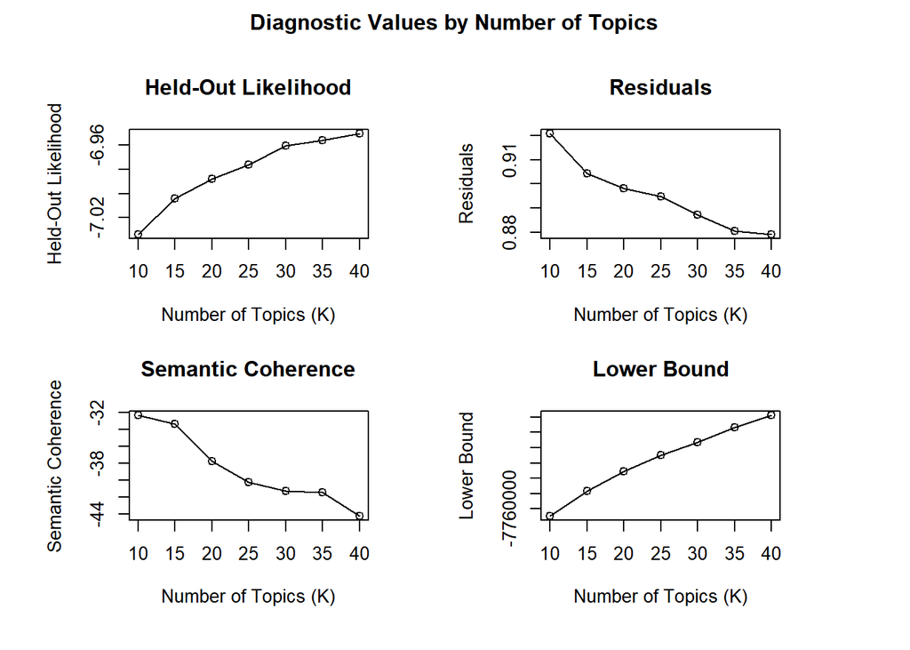

```r
plot(numtopics)
```

```r
# K =0 to figure out the optimal number of topics quickly
edgarfit_mgmt <- stm(documents = out$documents,
                     vocab = out$vocab,
                     K = 0,
                     prevalence =~ factor(GICS) + factor(GICS_sub) + s(date_filed),
                     max.em.its = 75,
                     data = out$meta,
                     reportevery=3,
                     # gamma.prior = "L1",
                     sigma.prior = 0.7,
                     init.type = "Spectral")
# visualise the topics
# topicQuality(edgarfit_mgmt, documents = out$documents)
# plot(edgarfit_mgmt,labeltype = "prob")
```

The optimal number of *65* is suggested. This is too large number of topics to interprete on. In addition, `semantic coherence` will be too weak (low) if topic numberis too large. If `semantic coherence` is too low, it can mean that the key words appear in a topic will have less consistency and makes the topic result unreliable. Therefore, I will stick to the `searchK` solution I have found previously (i.e. K = 35).

```r
# alternative stm K = 35
edgarfit_mgmt <- stm(documents = out$documents,
                        vocab = out$vocab,
                        K = 35,
                        prevalence =~ factor(GICS) + factor(GICS_sub) + s(date_filed),
                        max.em.its = 75,
                        data = out$meta,
                        reportevery=3,
                        # gamma.prior = "L1",
                        sigma.prior = 0.7,
                        init.type = "Spectral")

save(edgarfit_mgmt, file = "edgarfit_mgmt.rda")

# visualise the topics
topicQuality(edgarfit_mgmt, documents = out$documents)
plot(edgarfit_mgmt,labeltype = "prob")
```

```r
# make summary dataframe

topic_summary <- summary(edgarfit_mgmt)
topic_proportions <- colMeans(edgarfit_mgmt$theta)

topic_labels <- paste0("topic_",1:35)
table_towrite_labels <- data.frame()

# make summary table for topic results
for(i in 1:length(topic_summary$topicnums)){

  row_here <- tibble(topicnum= topic_summary$topicnums[i],
                     topic_label = topic_labels[i],
                     proportion = 100*round(topic_proportions[i],4),
                     frex_words = paste(topic_summary$frex[i,1:7],
                                        collapse = ", "))
  table_towrite_labels <- rbind(row_here,table_towrite_labels)
}

table_towrite_labels <- table_towrite_labels %>% arrange(topicnum)
```

```r
# brief check on the topics
for (i in 1:length(topic_summary$topicnums)) {
  cloud(edgarfit_mgmt,topic = i, max.words = 5)
}

thoughts <- out$meta %>% select(doc_id) %>% left_join(data_for_stm)
for (i in 1:length(topic_summary$topicnums)) {
  print(findThoughts(edgarfit_mgmt,texts = thoughts$annotated_text,topics=i,n=1))
}

# labelling topics
# from topic 1 to 35

label <- labelTopics(edgarfit_mgmt, n = 7)

# use frex measures labels
# to have balanced measure of labelling
# considering both word probability and exclusivity in a topic

topic_labels <- label$frex %>%
  as_tibble() %>%
  unite(col = labels, sep = "_") %>%
  pull()

table_towrite_labels$topic_label <- topic_labels

# back up
backup("edgar", "table_towrite_labels", table_towrite_labels)
```

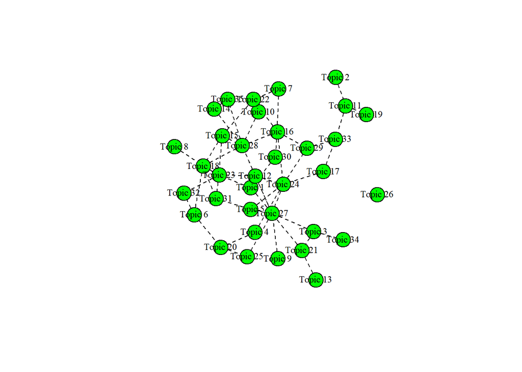

```r
# graphical view on the topic correlation
# shows which topics are related
corr <- topicCorr(edgarfit_mgmt)
plot(corr)

# most of the topics are generally related to each other
# only topic 26 is isolated (i.e. not correlated to any topics)
# topic 26: "tip_survey_depth_truck_road_engineer_voice"
```

With `stm` result and `labels` I obtained, I will figure out whether there is any significant (marginal) changes in topics across the industries, markets and time. Before using `estimateEffect` function to figure out the effect of `GICS`, `GICS_sub` and `date_filed`, they need to be transformed into numeric data. They have too large number of levels to be put as factors into prevalence formula, which may cause difficulties in interpreting the results. Even though the industries or markets have no levels between them (i.e. they are nominal categories, not ordinal), I set the levels to allocate them to specific number. In this way, they can be converted to numeric vector, so that I can recognise how the topics vary between industries and markets.

```r
# prepare metadata for estimateEffect function
# as GICS (industry) and GICS_sub (market) are non-numeirc
# they have to be transformed to numeric data type first

metadata <- out$meta %>%
  mutate(GICS = as.numeric(factor(GICS, levels = unique(data_for_stm$GICS))),
         GICS_sub = as.numeric(factor(GICS_sub, levels = unique(data_for_stm$GICS_sub))))

# estimate effect of Date filed, Industry sector and Market sector on the topics probability
# i.e. How topics probability(proportions) differ between time, GICS and GICS_sub
# covariate -> Industry, Market and Time
# s(date_filed) for spline function
# enables more smoothe curve of the time series
effects <- estimateEffect(~ s(date_filed) + GICS + GICS_sub,
                          stmobj = edgarfit_mgmt,
                          metadata = metadata)
# back up
save(effects, topic_labels, file =  "effects.rda")
```

**GICS trnasformation dictionary**

- from 1 to 11

[1] “Health Care” “Communication Services” “Consumer Staples”

[4] “Information Technology” “Utilities” “Industrials”

[7] “Materials” “Financials” “Energy”

[10] “Consumer Discretionary” “Real Estate”

**GICS_sub transformation dictionary**

- from 1 to 124

[1] “Health Care Distributors” “Movies & Entertainment”

[3] “Cable & Satellite” “Personal Products”

[5] “Technology Hardware, Storage & Peripherals” “Multi-Utilities”

[7] “Packaged Foods & Meats” “Airlines”

[9] “Railroads” “Paper Packaging”

[11] “Application Software” “Independent Power Producers & Energy Traders”

[13] “Internet Services & Infrastructure” “Investment Banking & Brokerage”

[15] “Oil & Gas Exploration & Production” “Internet & Direct Marketing Retail”

[17] “Specialized REITs” “Oil & Gas Equipment & Services”

[19] “Electrical Components & Equipment” “Electric Utilities”

[21] “Apparel, Accessories & Luxury Goods” “Oil & Gas Refining & Marketing”

[23] “Health Care Equipment” “Office REITs”

[25] “Life Sciences Tools & Services” “Oil & Gas Storage & Transportation”

[27] “Restaurants” “Hypermarkets & Super Centers”

[29] “Air Freight & Logistics” “Communications Equipment”

[31] “Industrial REITs” “Semiconductors”

[33] “Aerospace & Defense” “Hotels, Resorts & Cruise Lines”

[35] “Construction & Engineering” “IT Consulting & Other Services”

[37] “Financial Exchanges & Data” “Environmental & Facilities Services”

[39] “Retail REITs” “Distributors”

[41] “Household Appliances” “Trading Companies & Distributors”

[43] “Multi-Sector Holdings” “Hotel & Resort REITs”

[45] “Managed Health Care” “Apparel Retail”

[47] “Regional Banks” “Reinsurance”

[49] “Health Care Supplies” “Life & Health Insurance”

[51] “Data Processing & Outsourced Services” “Electronic Manufacturing Services”

[53] “Asset Management & Custody Banks” “Consumer Electronics”

[55] “Real Estate Services” “Insurance Brokers”

[57] “Property & Casualty Insurance” “Automotive Retail”

[59] “Gold” “Specialty Stores”

[61] “Casinos & Gaming” “Systems Software”

[63] “Specialized Consumer Services” “Multi-line Insurance”

[65] “Wireless Telecommunication Services” “Specialty Chemicals”

[67] “Fertilizers & Agricultural Chemicals” “Interactive Media & Services”

[69] “Thrifts & Mortgage Finance” “Consumer Finance”

[71] “Construction Materials” “Technology Distributors”

[73] “Water Utilities” “Tobacco”

[75] “Broadcasting” “Research & Consulting Services”

[77] “Industrial Machinery” “Automobile Manufacturers”

[79] “Distillers & Vintners” “Building Products”

[81] “Auto Parts & Equipment” “Pharmaceuticals”

[83] “Publishing” “Electronic Equipment & Instruments”

[85] “Drug Retail” “Industrial Gases”

[87] “Construction Machinery & Heavy Trucks” “Alternative Carriers”

[89] “Soft Drinks” “Household Products”

[91] “Brewers” “Electronic Components”

[93] “General Merchandise Stores” “Advertising”

[95] “Human Resource & Employment Services” “Biotechnology”

[97] “Semiconductor Equipment” “Health Care Facilities”

[99] “Home Improvement Retail” “Industrial Conglomerates”

[101] “Integrated Oil & Gas” “Leisure Products”

[103] “Oil & Gas Drilling” “Food Retail”

[105] “Home Furnishings” “Agricultural Products”

[107] “Diversified Banks” “Interactive Home Entertainment”

[109] “Diversified Support Services” “Department Stores”

[111] “Trucking” “Gas Utilities”

[113] “Steel” “Health Care REITs”

[115] “Residential REITs” “Computer & Electronics Retail”

[117] “Motorcycle Manufacturers” “Health Care Technology”

[119] “Housewares & Specialties” “Homebuilding”

[121] “Diversified Chemicals” “Health Care Services”

[123] “Metal & Glass Containers” “Food Distributors”

### Industry influence on topics

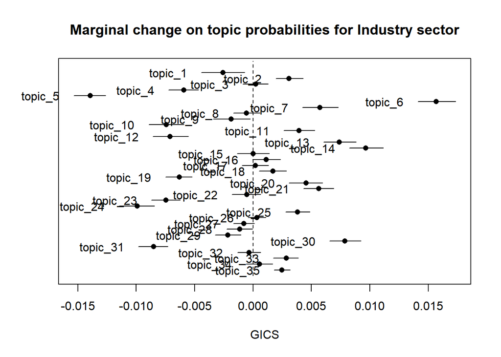

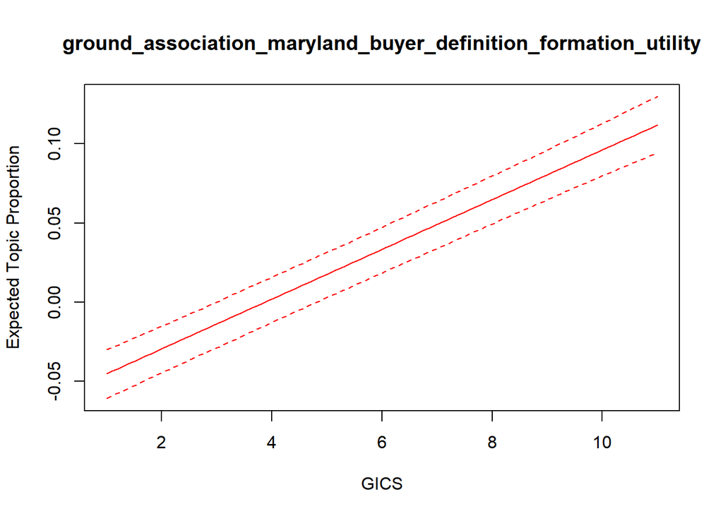

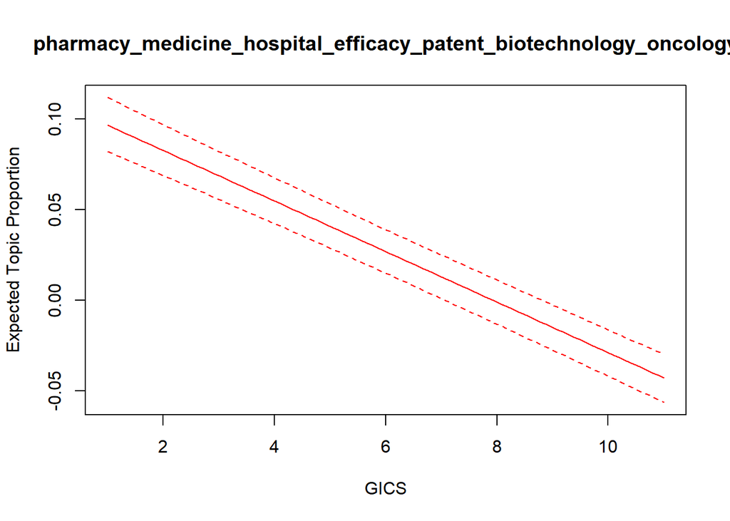

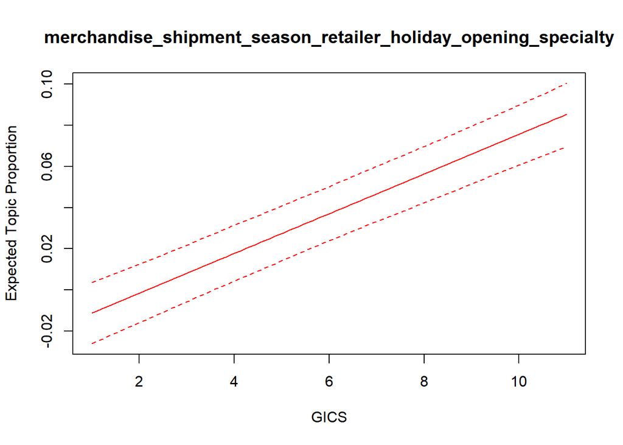

```r
## the effects of industries on topic probability

plot(effects,
     covariate = "GICS",
     topics = c(1:35),
     model = edgarfit_mgmt, method = "difference",
     cov.value1 = "100", cov.value2 = "0",
     xlab = "GICS",
     # xlim = c(-0.01,0.01),
     main = "Marginal change on topic probabilities for Industry sector",
     custom.labels = topic_labels,
     labeltype = "custom")

# linear relationship between each topic and industries

for(i in 1:length(topic_labels)){
  plot(effects, covariate = "GICS",
       topics = i,
       model = edgarfit_mgmt, method = "continuous",
       # For this plotting we get the uper quantile
       # and low quantile of the price
       xlab = "GICS",
       # xlim = c(0,1000),
       main = topic_labels[i],
       printlegend = FALSE,
       custom.labels =topic_labels[i],
       labeltype = "custom")
}

# top 3 topics
for(i in c(5, 6, 14)){
  plot(effects, covariate = "GICS",
       topics = i,
       model = edgarfit_mgmt, method = "continuous",
       # For this plotting we get the uper quantile
       # and low quantile of the price
       xlab = "GICS",
       # xlim = c(0,1000),
       main = topic_labels[i],
       printlegend = FALSE,
       custom.labels =topic_labels[i],
       labeltype = "custom")
}

summary(effects, topics = 5)
summary(effects, topics = 6)
summary(effects, topics = 14)
```

**top 3 topics seems to vary the most (industry level)**

- topic 6:`ground_association_maryland_buyer_definition_formation_utility` (more related to *higher* level industries in the dictionary) - p-value < 2e-16
- topic 5: `pharmacy_medicine_hospital_efficacy_patent_biotechnology_oncology` (more related to *lower* level industries in the dictionary) - p-value < 2e-16
- topic 14: `merchandise_shipment_season_retailer_holiday_opening_specialty` (more related to *higher* level industries in the dictionary) - p-value < 2e-16

These three topics show highest marginal change in probabilities across the industries among all topics. This means that *they seem to appear dominantly in certain industries (exclusitivity of topics with respect to industry sectors)*. Now I will figure out which industry these 3 topics are more likely to appear.

```r
theta <- as.data.frame(edgarfit_mgmt$theta)

# use topic number not label
# for convenience
colnames(theta) <- paste0("topic_", table_towrite_labels$topicnum)

GICS_theta_mean <- cbind(out$meta,theta) %>%
  select(GICS,13:47) %>%
  group_by(GICS) %>%
  summarise_at(vars(all_of(paste0("topic_", table_towrite_labels$topicnum))), mean)

# topic 6: ground_association_maryland_buyer_definition_formation_utility

GICS_theta_mean %>%
  select(GICS, topic_6) %>%
  arrange(desc(topic_6))

# topic 5: pharmacy_medicine_hospital_efficacy_patent_biotechnology_oncology

GICS_theta_mean %>%
  select(GICS, topic_5) %>%
  arrange(desc(topic_5))

# topic 14: merchandise_shipment_season_retailer_holiday_opening_specialty

GICS_theta_mean %>%
  select(GICS, topic_14) %>%
  arrange(desc(topic_14))

rm(GICS_theta_mean)
gc()
```

**About top 3 topics - Which industries do they appear the most? (top 2)**

(Higher theta indicates higher proportion of a topic appears)

- topic 6:`ground_association_maryland_buyer_definition_formation_utility`

rank 1. Real estate - mean theta 0.4942419059

rank 2. Consumer Discretionary - mean theta 0.0388435634

- topic 5: `pharmacy_medicine_hospital_efficacy_patent_biotechnology_oncology`

rank 1. Health Care - mean theta 0.2263613

rank 2. Consumer Staples - mean theta 0.009111501

- topic 14: `merchandise_shipment_season_retailer_holiday_opening_specialty`

rank 1. Consumer Discretionary - 0.1801082677

rank 2. Consumer Staples - 0.0304000571

### Market influence on topics

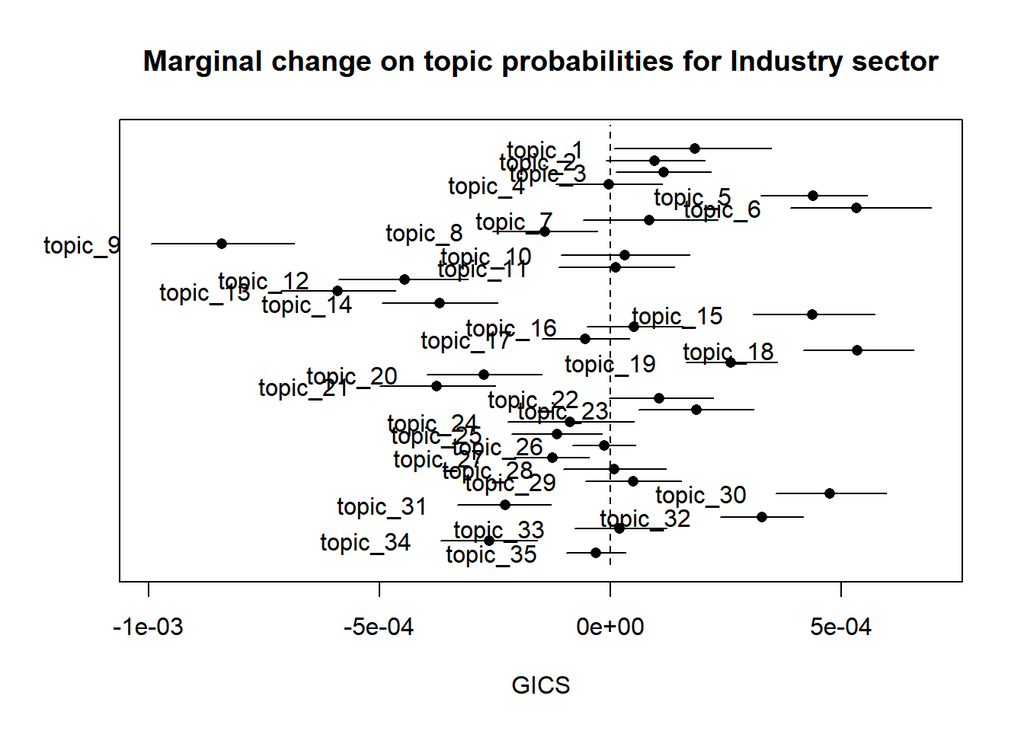

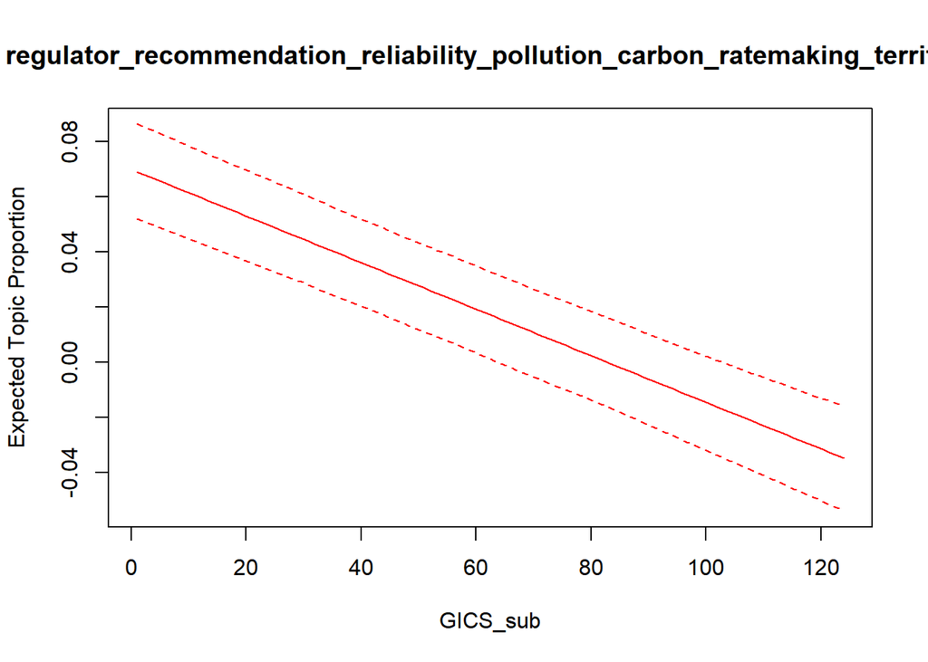

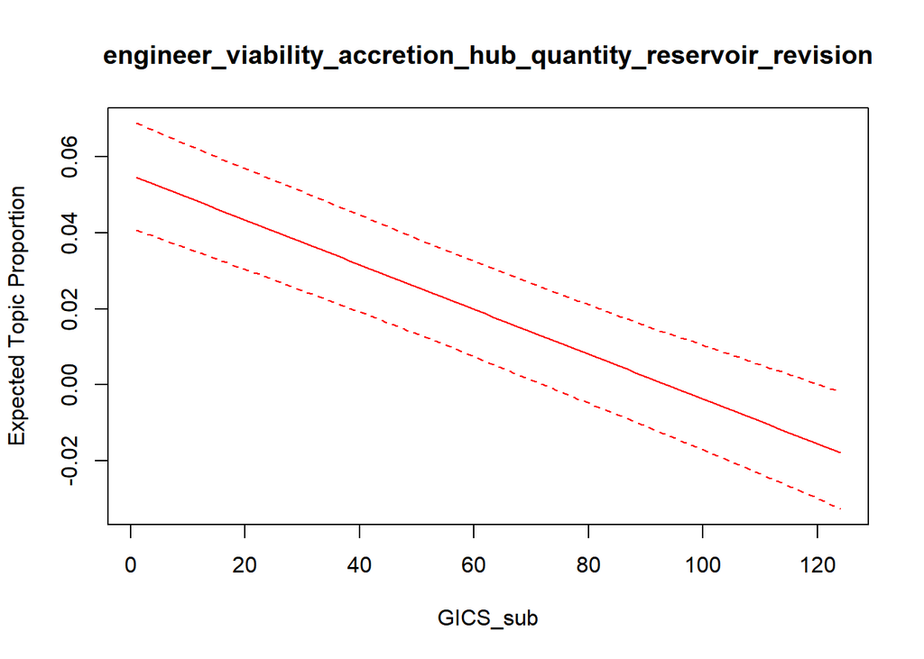

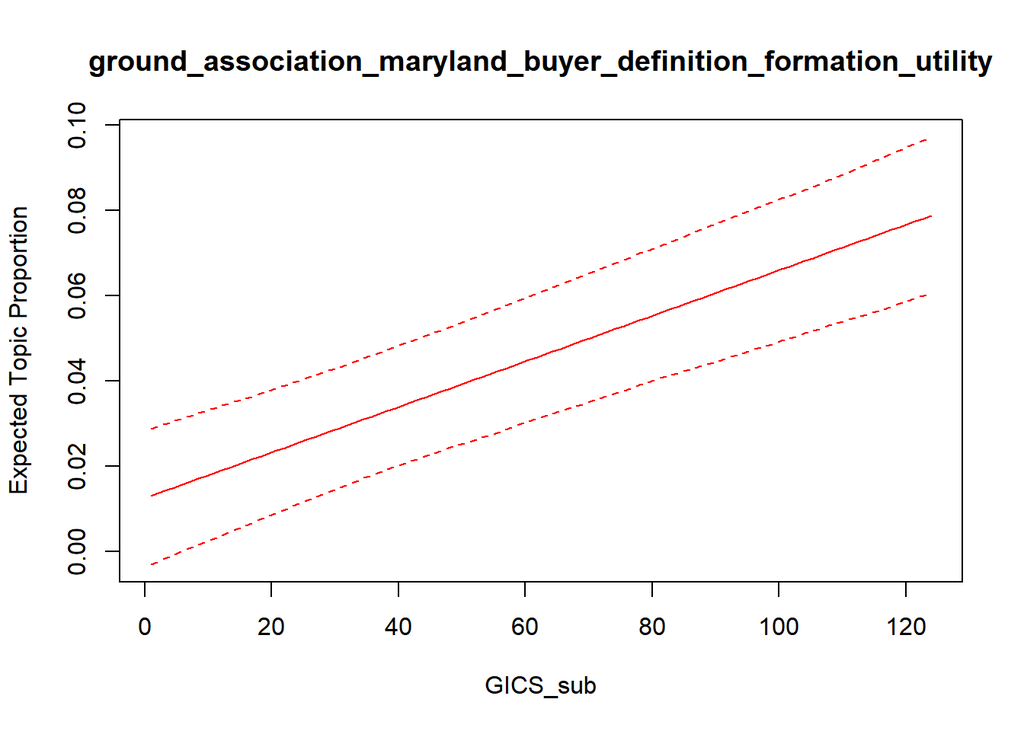

```r
## the effects of markets on topic probability

plot(effects,
     covariate = "GICS_sub",
     topics = c(1:35),
     model = edgarfit_mgmt, method = "difference",
     cov.value1 = "100", cov.value2 = "0",
     xlab = "GICS",
     # xlim = c(-0.01,0.01),
     main = "Marginal change on topic probabilities for Industry sector",
     custom.labels = topic_labels,
     labeltype = "custom")

# linear relationship between each topic and markets

for(i in 1:length(topic_labels)){
  plot(effects, covariate = "GICS_sub",
       topics = i,
       model = edgarfit_mgmt, method = "continuous",
       # For this plotting we get the uper quantile
       # and low quantile of the price
       xlab = "GICS_sub",
       # xlim = c(0,1000),
       main = topic_labels[i],
       printlegend = FALSE,
       custom.labels =topic_labels[i],
       labeltype = "custom")
}

# display top 3 topics
for(i in c(6, 9, 13)){
  plot(effects, covariate = "GICS_sub",
       topics = i,
       model = edgarfit_mgmt, method = "continuous",
       # For this plotting we get the uper quantile
       # and low quantile of the price
       xlab = "GICS_sub",
       # xlim = c(0,1000),
       main = topic_labels[i],
       printlegend = FALSE,
       custom.labels =topic_labels[i],
       labeltype = "custom")
}

summary(effects, topics = 6)
summary(effects, topics = 9)
summary(effects, topics = 13)
```

**top 3 topics seems to vary the most (market level)**

- topic 9: `regulator_recommendation_reliability_pollution_carbon_ratemaking_territory` (more related to *lower* level markets in the dictionary) - p-value < 2e-16
- topic 13: `engineer_viability_accretion_hub_quantity_reservoir_revision` (more related to *lower* level markets in the dictionary) - p-value <2e-16
- topic 6: `ground_association_maryland_buyer_definition_formation_utility` (more related to *higher* level markets in the dictionary) - p-value = 5.35e-12

These three topics show highest marginal change in probabilities across the markets among all topics. This means that *they seem to appear dominantly in certain markets (exclusitivity of topics with respect to market sectors)*. Now I will figure out which market these 3 topics are more likely to appear.

```r
GICS_sub_theta_mean <- cbind(out$meta,theta) %>%
  select(GICS_sub,13:47) %>%
  group_by(GICS_sub) %>%
  summarise_at(vars(all_of(paste0("topic_", table_towrite_labels$topicnum))), mean)

# topic 9: `regulator_recommendation_reliability_pollution_carbon_ratemaking_territory`

GICS_sub_theta_mean %>%
  select(GICS_sub, topic_9) %>%
  arrange(desc(topic_9))

# topic 13: `engineer_viability_accretion_hub_quantity_reservoir_revision`

GICS_sub_theta_mean %>%
  select(GICS_sub, topic_13) %>%
  arrange(desc(topic_13))

# topic 6: `ground_association_maryland_buyer_definition_formation_utility`

GICS_sub_theta_mean %>%
  select(GICS_sub, topic_6) %>%
  arrange(desc(topic_6))

rm(GICS_sub_theta_mean)
gc()
```

**About top 3 topics - Which markets do they appear the most? (top 5)**

(Higher theta indicates higher proportion of a topic appears)

- topic 9: `regulator_recommendation_reliability_pollution_carbon_ratemaking_territory`

rank 1. Electric Utilities - mean theta 0.7510207

rank 2. Multi-Utilities - mean theta 0.7037211

rank 3. Water Utilities - mean theta 0.4508054

rank 4. Independent Power Producers & Energy Traders - mean theta 0.4406535

rank 5. Gas Utilities - mean theta 0.4268549

- topic 13: `engineer_viability_accretion_hub_quantity_reservoir_revision`

rank 1. Oil & Gas Exploration & Production - mean theta 0.6866182

rank 2. Integrated Oil & Gas - mean theta 0.5482505

rank 3. Gold - mean theta 0.2782034

rank 4. Oil & Gas Equipment & Services - mean theta 0.2260516

rank 5. Oil & Gas Drilling - mean theta 0.1890175

- topic 6: `ground_association_maryland_buyer_definition_formation_utility`

rank 1. Retail REITs - mean theta 0.7610708

rank 2. Office REITs - mean theta 0.7200422

rank 3. Residential REITs - mean theta 0.6461352

rank 4. Industrial REITs - mean theta 0.4911548

rank 5. Homebuilding - mean theta 0.4501610

### Time influence on topics

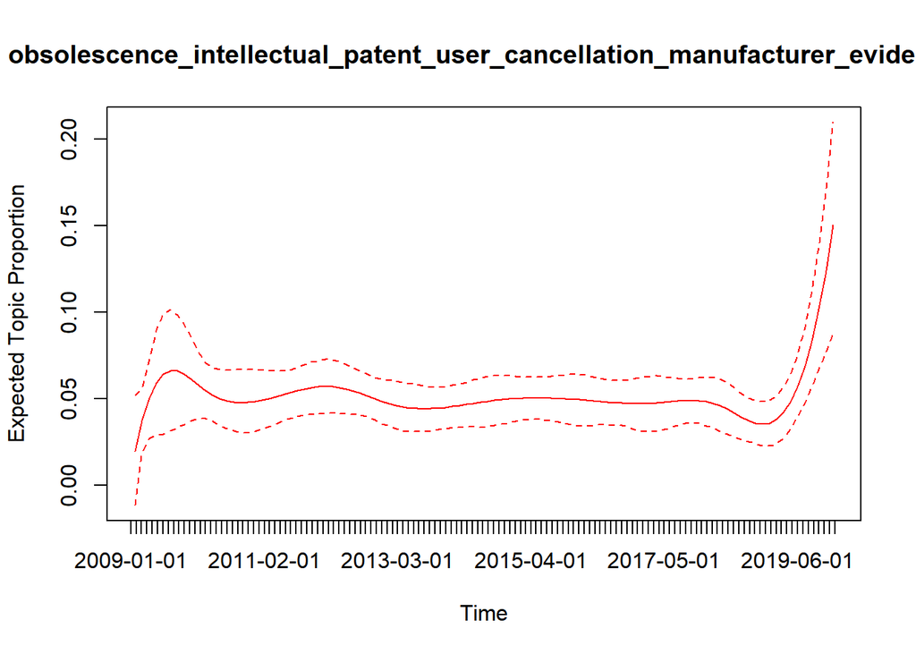

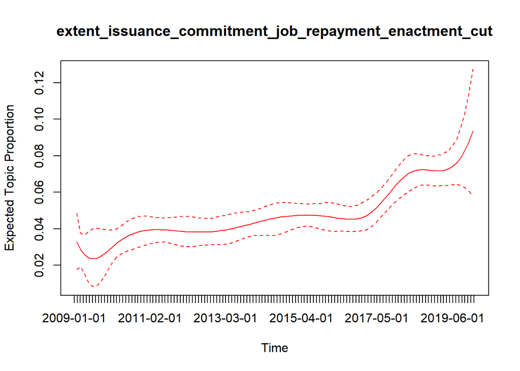

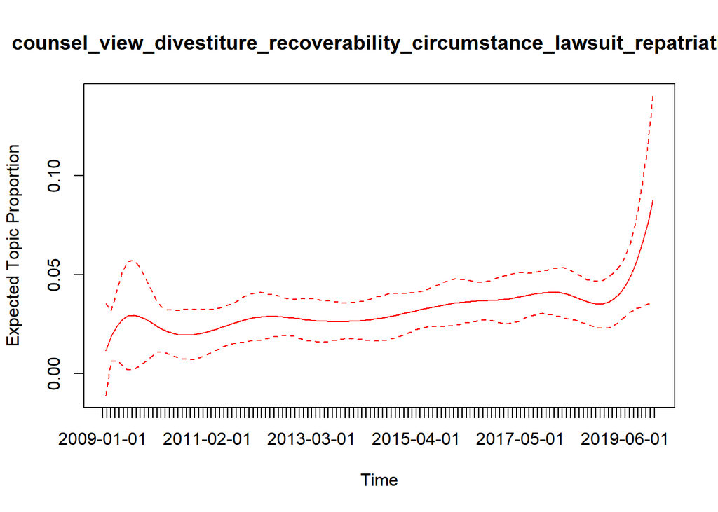

```r
# topic changes according to time

monthseq <- seq(from = as.Date("2009-01-01"),
                to = as.Date("2020-01-01"), by = "month")

time_topic <- list()

for (i in 1:length(topic_labels)) {
  x <- plot(effects,
     "date_filed",
     method = "continuous", topics = i,
     main = topic_labels[i],
     model = edgarfit_mgmt,
     printlegend = FALSE,
     xaxt = "n",
     xlab = "Time",
     custom.labels =topic_labels[i],
     labeltype = "custom")

  axis(1,
     at =  as.numeric(monthseq),
     labels = as.character(monthseq))
}

for (i in c(12, 27, 28)) {
  x <- plot(effects,
     "date_filed",
     method = "continuous", topics = i,
     main = topic_labels[i],
     model = edgarfit_mgmt,
     printlegend = FALSE,
     xaxt = "n",
     xlab = "Time",
     custom.labels =topic_labels[i],
     labeltype = "custom")

  axis(1,
     at =  as.numeric(monthseq),
     labels = as.character(monthseq))
}

summary(effects, topics = 12)
summary(effects, topics = 27)
summary(effects, topics = 28)
```

**Topic 12, 27, 28 show a certain changes in their proportions depending on the time.**

- Topic 12 - (`obsolescence_intellectual_patent_user_cancellation_manufacturer_evidence`)

topic proportion starts to grow up since the start of 2019 as shown in the graph and statistical evidence (`confidence interval and p-value`) also shows that this increase is significant.

- Topic 27 - (`extent_issuance_commitment_job_repayment_enactment_cut`) topic proportion

topic proportion starts to increase since the start of 2017 and statistical evidence (`confidence interval and p-value`) supports this trend.

- topic 28 - (`counsel_view_divestiture_recoverability_circumstance_lawsuit_repatriation`)

topic proportion starts to rapidly increase since the start of 2019 and statistical evidence (`confidence interval and p-value`) supports this trend.

However, most of the topics except these three topics seem to have no clear trends across the date of the filing, as shown in the graphs. Their `confidence intervals` (wide dotted lines) and summary of the effects (high `p values`) indicates that most of these influences of time on the topics not significant. Therefore, I concluded that *‘generally, some topics seem to be able to have tendency of up and down depending on the time difference, but it is difficult to say all those trends are significant’*.

## Additional predictibility of topics on stock price

```r
# prepare data set for regression analysis
for_regression <- cbind(out$meta,theta)

# I chose `SentimentLM` as starting independent variable
# based on the previous analysis results
# I will add on some topics as independent variable
# to check if it adds on additional predictibility on stock price change

# statistical check (pre-processing)
# same as part B 10-K
# to keep the consistency of the analysis

q_price <- quantile(for_regression$price_diff, probs = seq(0,1,0.001))
q_lm <- quantile(for_regression$SentimentLM, probs = seq(0,1,0.001))
# trimmed the price_diff data to remove some possible outliers (i.e. extreme values)

lower_q_price <- q_price[[11]]
upper_q_price <- q_price[[length(q_price)-11]]
lower_q_lm <- q_lm[[5]]

for_regression_filtered <- for_regression %>%
  filter(price_diff >= lower_q_price,
         price_diff <= upper_q_price,
         SentimentLM >= lower_q_lm
         )


# figure out which topics seem to have possible predictibility on stock price movement
# try simple linear regression
# iteratively putting topic into independent variable one by one
# and figure out significant topics

model <- lm(ihs(price_diff) ~ topic_1, data=for_regression_filtered)

summary(model)

# SentimentLM - p-value: 0.0375
# topic_1 - p-value: 0.045
# topic_5 - p-value: 0.0495
# topic_13 - p-value: 0.0119

rm(model)
gc()
```

**independent variables:**

- SentimentLM
- topic_1 - `disclosure_policy_judgment_interpretation_position_accordance_valuation`
- topic_5 - `pharmacy_medicine_hospital_efficacy_patent_biotechnology_oncology`
- topic_13 - `engineer_viability_accretion_hub_quantity_reservoir_revision`

```r
model_1 <- lm(ihs(price_diff) ~ SentimentLM,
              data=for_regression_filtered)

model_2 <- lm(ihs(price_diff) ~ SentimentLM + topic_1,
              data=for_regression_filtered)

model_3 <- lm(ihs(price_diff) ~ SentimentLM + topic_1 + topic_5,
              data=for_regression_filtered)

model_4 <- lm(ihs(price_diff) ~ SentimentLM + topic_1 + topic_5 + topic_13,
              data=for_regression_filtered)

# check linearity
# library(lmtest)
# lrtest(model_1,model_2,model_3,model_4)

anova(model_4)

# anova result shows that adding topic_5 do not have additive predictibility on the model
# therefore final model is as follows
rm(model_1, model_2, model_3, model_4)
gc()
```

```r
model_1 <- lm(ihs(price_diff) ~ SentimentLM,
              data=for_regression_filtered)

model_2 <- lm(ihs(price_diff) ~ SentimentLM + topic_1,
              data=for_regression_filtered)

model_final <- lm(ihs(price_diff) ~ SentimentLM + topic_1 + topic_13,
              data=for_regression_filtered)

stargazer::stargazer(model_1,model_2,model_final, type = "text",header = FALSE,
          star.cutoffs = c(0.05,0.01,0.001))

summary(model_final)
```

**final model summary:**

- `SentimentLM`: Marginal increase in Loughran and McDonald sentiment score can significantly *increase* the amount of price change after the filing by 0.96799 (t = 2.037, p-value = 0.0417)
- `disclosure_policy_judgment_interpretation_position_accordance_valuation`: Marginal increase in the proportion (theta) of `topic_1` significantly *decrease* the amount of price change after the filing by 0.1997 (t = -2.052, p-value = 0.0403)
- `engineer_viability_accretion_hub_quantity_reservoir_revision`: Marginal increase in the proportion (theta) of `topic_13` significantly *decrease* the amount of price change after the filing by 0.29088 (t = -2.557, p-value = 0.0106)
- The overall model fit increased gradually according to `R2` and `Adjusted R2`. However, the model fit is pretty bad as R2 is only 0.004 in the final model. Therefore, further investigation on more powerful predicting variables are required to increase the model predictibility.

R2 0.001 0.002 0.004  
Adjusted R2 0.001 0.002 0.003